# TD2 Regression linéaire simple, multiple et analyse de la variance

Antoine Bichat - Émilie Lebarbier

# Préliminaires

## Librairies

```r
library(ppcor)
library(car)
library(tidyverse)
# library(ggplot2) # déjà chargé avec tidyverse
```

## Chargement des données

```r
myData <- read.table(file = "bats.csv", sep = ";", skip= 3, header = TRUE)
str(myData)
```

```
## 'data.frame':    63 obs. of  8 variables:
##  $ Species: Factor w/ 63 levels " Anoura  geofroyi ",..: 52 20 19 12 16 17 47 29 55 41 ...
##  $ Diet   : int  1 1 1 1 1 1 1 1 1 1 ...
##  $ Clade  : Factor w/ 4 levels "I","II","III",..: 1 1 1 1 1 1 1 1 1 1 ...
##  $ BOW    : num  136.3 120 58.7 48.3 184 ...
##  $ BRW    : num  2070 2210 1310 1184 3028 ...
##  $ AUD    : num  9.88 10.44 5.48 4.77 7.09 ...
##  $ MOB    : num  105.8 107.8 67 65.3 213.4 ...
##  $ HIP    : num  126 159.8 97.7 95.4 233.3 ...
```

`Diet` est ici un entier, on va donc changer sa classe en facteur car cette variable est en réalité catégorielle.

```r
myData$Diet <- as.factor(myData$Diet)
# ou de manière équivalente
# myData <- mutate(myData, Diet = as.factor(Diet))
```

# Étude du lien entre le poids du cerveau et la masse corporelle

## Sélection des phytophages

Les phytophages correspondent à la diète $1$.

```r
phyto <- myData[myData$Diet == 1, ]
# ou de manière équivalente
# phyto <- filter(myData, Diet == 1)
```

```r
head(phyto)
```

```
##                    Species Diet Clade   BOW     BRW   AUD    MOB    HIP
## 1  Rousettus  aegyptiacus     1     I 136.3 2070.00  9.88 105.77 125.97
## 2      Epomops  franqueti     1     I 120.0 2210.00 10.44 107.80 159.80
## 3     Eonycteris  spelaea     1     I  58.7 1310.00  5.48  67.00  97.70
## 4      Cynopterus  sphinx     1     I  48.3 1184.33  4.77  65.27  95.40
## 5    Dobsonia  praedatrix     1     I 184.0 3028.00  7.09 213.43 233.30
## 6         Eidolon  helvum     1     I 262.0 4290.00 12.77 208.70 258.10
```

```r
tail(phyto)
```

```
##                    Species Diet Clade  BOW  BRW   AUD   MOB   HIP
## 37  Rhinophlylla  pumilio     1    II  8.9  356  4.57 18.80 30.30
## 38       Sturnira  lilium     1    II 20.2  618  4.77 30.77 49.73
## 39    Artibeus  lituratus     1    II 41.0 1016  7.21 34.38 54.90
## 40    Uroderma  bilobatum     1    II 16.2  612  5.98 28.70 42.70
## 41    Vampyrops  vittatus     1    II 22.6  791 11.56 29.22 52.46
## 42   Chiroderma  villosum     1    II 26.1  814  7.95 28.75 47.58
```

## Nuage de points

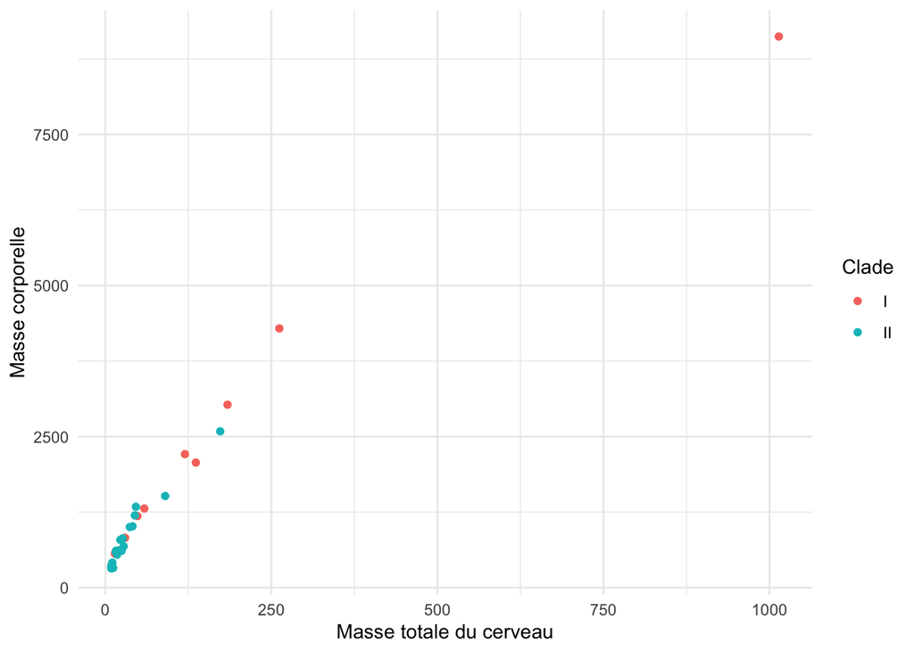

```r
ggplot(phyto) +
   aes(x = BOW, y = BRW, color = Clade) +
   geom_point() +
   theme_minimal() +
   labs(x = "Masse totale du cerveau", y = "Masse corporelle")
```

## Régression linéaire simple

### Modèle

On cherche à modéliser la masse du cerveau en fonction de la masse corporelle. Le modèle mathématique associé est donc

$$Y_i = a + b x_i + E_i,$$

où

- $Y_i$ est la masse du cerveau de l’individu $i$,
- $x_i$ est la masse corporelle de l’individu $i$,
- $\left\{E_i\right\} \overset{iid}{\sim} \mathcal{N}\left(0, \sigma^2\right)$,
- $1 \leq i \leq n = 29$.

```r
reg1 <- lm(BRW ~ BOW, data = phyto)
reg1
```

```
##
## Call:
## lm(formula = BRW ~ BOW, data = phyto)
##
## Coefficients:
## (Intercept)          BOW
##       623.4          9.0
```

### Graphes de diagnostic

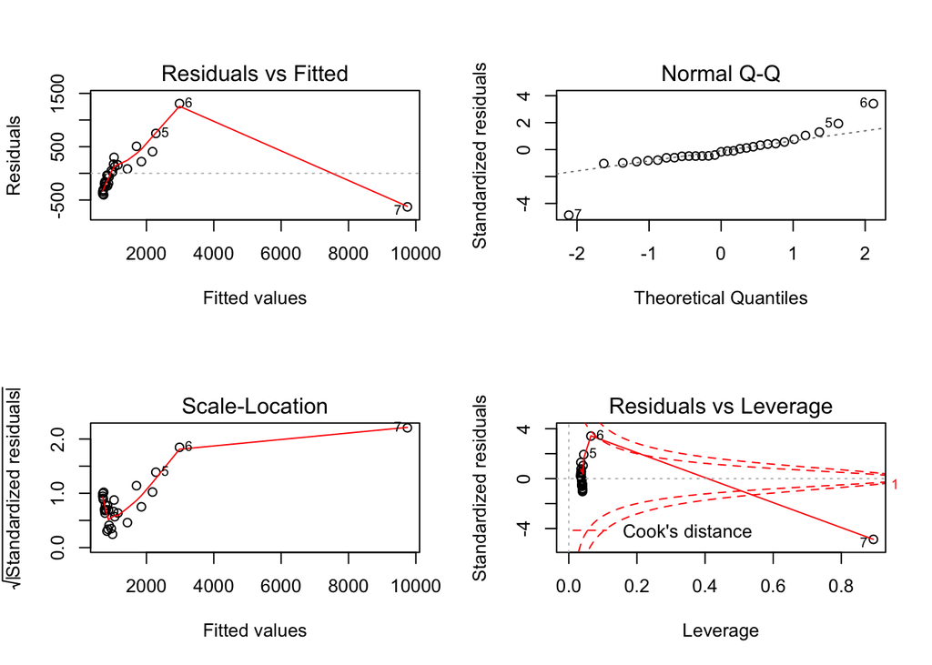

```r
par(mfrow = c(2, 2))
plot(reg1)
```

On observe que le point 7 est atypique avec une distance de Cook supérieure à 1. En vérifiant avec `cooks.distance(reg1)`, on s’aperçoit qu’elle vaut 100.08. On décide donc de la retirer des observations.

### Nouveau modèle

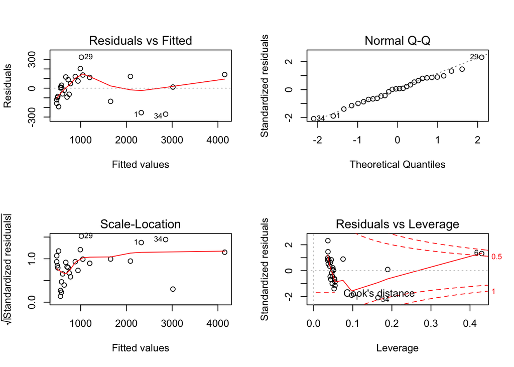

```r
phyto_sub <- phyto[-7, ]
reg2 <- lm(BRW ~ BOW, data = phyto_sub)
par(mfrow = c(2, 2))
plot(reg2)
```

Les graphes sont nettement plus proches de ce que l’on peut attendre lorsqu’on a des hypothèses respectées. Notons toutefois qu’on observe une tendance dans la moyenne (premier graphe) et une tendance dans la variance (troisième graphe) pour les petites valeurs ajustées. La normalité est validée et le point $6$ est atypique mais nous allons le garder pour la suite de l’analyse.

Dans une analyse réelle qui sort du cadre formel de ce TP, on retirerait itérativement les points atypiques, à commencer par le point $6$.

### Test du modèle

```r
reg2_0 <- lm(BRW ~ 1, data = phyto_sub)
anova(reg2_0, reg2)
```

```
## Analysis of Variance Table
##
## Model 1: BRW ~ 1
## Model 2: BRW ~ BOW
##   Res.Df      RSS Df Sum of Sq      F    Pr(>F)
## 1     27 23562448
## 2     26   522490  1  23039958 1146.5 < 2.2e-16 ***
## ---
## Signif. codes:  0 '***' 0.001 '**' 0.01 '*' 0.05 '.' 0.1 ' ' 1
```

On effectue le test $H_0 = \{b = 0\}$ contre $H_1 = \{b \neq 0\}$. La statistique de test est $F_{obs}= 1146.5$ et on a $p<0.05$. On peut donc rejeter l’hypothèse nulle : notre modèle est significatif.

On note par ailleurs que

- la somme des carrés totale vaut $23562448$ sur $27$ degrés de liberté,
- la somme des carrés résiduelle vaut $522490$ sur $26$ degrés de liberté,
- la somme des carrés due au modèle vaut $23039958$ sur $1$ degré de liberté.

### Estimation des coefficients et du $R^2$

```r
summary(reg2)
```

```
##
## Call:
## lm(formula = BRW ~ BOW, data = phyto_sub)
##
## Residuals:
##     Min      1Q  Median      3Q     Max
## -269.76  -93.33    8.73  112.93  322.55
##
## Coefficients:
##             Estimate Std. Error t value Pr(>|t|)
## (Intercept) 346.5452    35.4920   9.764 3.48e-10 ***
## BOW          14.5099     0.4285  33.860  < 2e-16 ***
## ---
## Signif. codes:  0 '***' 0.001 '**' 0.01 '*' 0.05 '.' 0.1 ' ' 1
##
## Residual standard error: 141.8 on 26 degrees of freedom
## Multiple R-squared:  0.9778, Adjusted R-squared:  0.977
## F-statistic:  1147 on 1 and 26 DF,  p-value: < 2.2e-16
```

L’ordonnée à l’origine vaut $346.5452$ et la pente $14.5099>0$ donc plus la masse corporelle augmente, plus la masse totale du cerveau augmente.

On note que le coefficient de determination $R^2$ vaut $0.9778$ donc le modèle a un fort pouvoir prédictif.

# Influence de chaque partie du cerveau

## Corrélation entre les variables numériques

```r
phytoNum <- phyto[, 4:8]
# ou de manière équivalente
# phytoNum <- select(phyto, BOW, BRW, AUD, MOB, HIP)
# ou de manière équivalente
# phytoNum <- select_if(phyto, is.numeric)
```

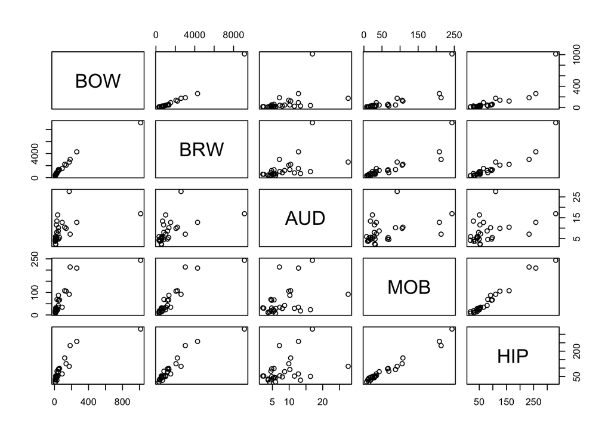

```r
plot(phytoNum)
```

```r
cor(phytoNum)
```

```
##           BOW       BRW       AUD       MOB       HIP
## BOW 1.0000000 0.9746992 0.4634708 0.7784065 0.8361110
## BRW 0.9746992 1.0000000 0.5283792 0.8834215 0.9276811
## AUD 0.4634708 0.5283792 1.0000000 0.4096192 0.4190464
## MOB 0.7784065 0.8834215 0.4096192 1.0000000 0.9856097
## HIP 0.8361110 0.9276811 0.4190464 0.9856097 1.0000000
```

```r
pcor(phytoNum)$estimate
```

```
##            BOW        BRW        AUD        MOB        HIP
## BOW  1.0000000  0.9867279 -0.8124408  0.1768331 -0.7071405
## BRW  0.9867279  1.0000000  0.8452198 -0.2588062  0.7830200
## AUD -0.8124408  0.8452198  1.0000000  0.2733892 -0.6910170
## MOB  0.1768331 -0.2588062  0.2733892  1.0000000  0.7867850
## HIP -0.7071405  0.7830200 -0.6910170  0.7867850  1.0000000
```

On note que dans la corrélation entre `MOB` et `BRW` est positive alors que `MOB` est négativement associée à `BRW` dans une corrélation partielle (quand on prend en compte l’effet des autres variables).

## Regression linéaire multiple

### Modèle

On cherche à modéliser la masse du cerveau en fonction d’autres variables quantitatives Le modèle mathématique associé est donc

$$Y_i = \beta_0 + \beta_1 x_{i,1} + \beta_2 x_{i,2} + \beta_3 x_{i,3} + E_i,$$

où

- $Y_i$ est la masse du cerveau de l’individu $i$,
- $x_{i,1}$ est le volume de la partie auditive de l’individu $i$,
- $x_{i,2}$ est le volume de la zone olfactive de l’individu $i$,
- $x_{i,3}$ est le volume de l’hippocampe de l’individu $i$,
- $\left\{E_i\right\} \overset{iid}{\sim} \mathcal{N}\left(0, \sigma^2\right)$,
- $1 \leq i \leq n = 29$.

```r
reg3 <- lm(BRW ~ AUD + MOB + HIP, data = phytoNum)
```

### Graphes de diagnostic

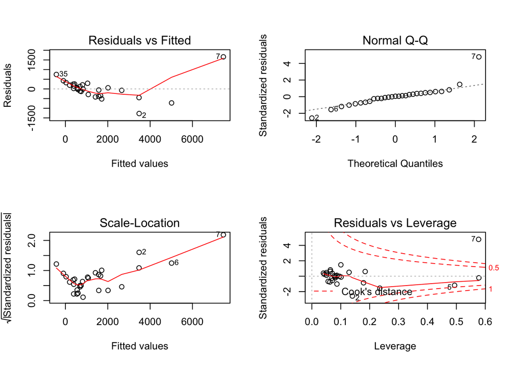

```r
par(mfrow = c(2, 2))
plot(reg3)
```

- On observe une tendance dans la moyenne.
- On valide la normalité.
  - De plus, on ne peut pas rejeter l’hypothèse nulle du test de Shapiro `shapiro.test(reg3$residuals)`.
- On observe une tendance dans la variance.
- Le point $7$ est atypique.

### Test du modèle

```r
reg3_0 <- lm(BRW ~ 1, data = phytoNum) # et pas phyto_sub !
anova(reg3_0, reg3)
```

```
## Analysis of Variance Table
##
## Model 1: BRW ~ 1
## Model 2: BRW ~ AUD + MOB + HIP
##   Res.Df      RSS Df Sum of Sq      F    Pr(>F)
## 1     28 85142218
## 2     25  7112426  3  78029792 91.424 1.317e-13 ***
## ---
## Signif. codes:  0 '***' 0.001 '**' 0.01 '*' 0.05 '.' 0.1 ' ' 1
```

On effectue le test $H_0 = \{\forall i\geq1, \beta_i = 0\}$ contre $H_1 = \{\exists i\geq1, \beta_i \neq 0\}$. La statistique de test est $F_{obs}= 91.424$ et on a $p<0.05$. On peut donc rejeter l’hypothèse nulle : notre modèle est significatif et au moins une des variables a de l’influence.

On note par ailleurs que

- la somme des carrés totale vaut $85142218$ sur $28$ degrés de liberté,
- la somme des carrés résiduelle vaut $7112426$ sur $25$ degrés de liberté,
- la somme des carrés due au modèle vaut $78029792$ sur $3$ degrés de liberté.

### Test des différentes variables

```r
anova(reg3)
```

```
## Analysis of Variance Table
##
## Response: BRW
##           Df   Sum Sq  Mean Sq F value    Pr(>F)
## AUD        1 23770396 23770396  83.552 1.903e-09 ***
## MOB        1 45514106 45514106 159.981 2.306e-12 ***
## HIP        1  8745291  8745291  30.739 9.179e-06 ***
## Residuals 25  7112426   284497
## ---
## Signif. codes:  0 '***' 0.001 '**' 0.01 '*' 0.05 '.' 0.1 ' ' 1
```

- `AUD` apporte de l’information de manière significative sur `BRW`,
- `MOB` apporte de l’information de manière significative en plus de `AUD` sur `BRW`,
- `HIP` apporte de l’information de manière significative en plus de `AUD` et `MOB` sur `BRW`.

```r
Anova(reg3)
```

```
## Anova Table (Type II tests)
##
## Response: BRW
##            Sum Sq Df F value    Pr(>F)
## AUD       1910121  1  6.7140  0.015740 *
## MOB       2743277  1  9.6426  0.004683 **
## HIP       8745291  1 30.7395 9.179e-06 ***
## Residuals 7112426 25
## ---
## Signif. codes:  0 '***' 0.001 '**' 0.01 '*' 0.05 '.' 0.1 ' ' 1
```

- l’effet marginal de `AUD` (en plus de `MOB` et `HIP`) sur `BRW` est significatif,
- l’effet marginal de `MOB` (en plus de `AUD` et `HIP`) sur `BRW` est significatif,
- l’effet marginal de `HIP` (en plus de `AUD` et `MOB`) sur `BRW` est significatif.

```r
summary(reg3)
```

```
##
## Call:
## lm(formula = BRW ~ AUD + MOB + HIP, data = phytoNum)
##
## Residuals:
##      Min       1Q   Median       3Q      Max
## -1272.35  -287.80    24.65   209.64  1659.56
##
## Coefficients:
##              Estimate Std. Error t value Pr(>|t|)
## (Intercept) -1003.952    213.483  -4.703 8.05e-05 ***
## AUD            52.819     20.385   2.591  0.01574 *
## MOB           -29.243      9.417  -3.105  0.00468 **
## HIP            44.351      7.999   5.544 9.18e-06 ***
## ---
## Signif. codes:  0 '***' 0.001 '**' 0.01 '*' 0.05 '.' 0.1 ' ' 1
##
## Residual standard error: 533.4 on 25 degrees of freedom
## Multiple R-squared:  0.9165, Adjusted R-squared:  0.9064
## F-statistic: 91.42 on 3 and 25 DF,  p-value: 1.317e-13
```

Les p-valeurs de cette table sont les mêmes que celles de l’instruction `Anova()` (type II).

Le coeffidient associé à `AUD` est $52.819>0$, celui de `MOB` est $-29.243<0$ et celui de `HIP` est $44.351>0$.

`MOB` est négativement associé à `BRW`, ce qui est logique car le coefficient de corrélation partiel obtenu plus tôt l’était aussi.

### Selection *forward*

```r
step(reg3_0, scope = BRW ~ AUD + MOB + HIP, direction = "forward")
```

```
## Start:  AIC=433.88
## BRW ~ 1
##
##        Df Sum of Sq      RSS    AIC
## + HIP   1  73272731 11869487 378.74
## + MOB   1  66447848 18694370 391.92
## + AUD   1  23770396 61371823 426.39
## <none>              85142218 433.88
##
## Step:  AIC=378.74
## BRW ~ HIP
##
##        Df Sum of Sq      RSS    AIC
## + MOB   1   2846939  9022548 372.79
## + AUD   1   2013783  9855704 375.35
## <none>              11869487 378.74
##
## Step:  AIC=372.79
## BRW ~ HIP + MOB
##
##        Df Sum of Sq     RSS    AIC
## + AUD   1   1910121 7112426 367.89
## <none>              9022548 372.79
##
## Step:  AIC=367.89
## BRW ~ HIP + MOB + AUD
```

```
##
## Call:
## lm(formula = BRW ~ HIP + MOB + AUD, data = phytoNum)
##
## Coefficients:
## (Intercept)          HIP          MOB          AUD
##    -1003.95        44.35       -29.24        52.82
```

Le modèle selectionné est le modèle complet.

### Selection *stepwise*

```r
step(reg3_0, scope = BRW ~ AUD + MOB + HIP, direction = "both")
```

```
## Start:  AIC=433.88
## BRW ~ 1
##
##        Df Sum of Sq      RSS    AIC
## + HIP   1  73272731 11869487 378.74
## + MOB   1  66447848 18694370 391.92
## + AUD   1  23770396 61371823 426.39
## <none>              85142218 433.88
##
## Step:  AIC=378.74
## BRW ~ HIP
##
##        Df Sum of Sq      RSS    AIC
## + MOB   1   2846939  9022548 372.79
## + AUD   1   2013783  9855704 375.35
## <none>              11869487 378.74
## - HIP   1  73272731 85142218 433.88
##
## Step:  AIC=372.79
## BRW ~ HIP + MOB
##
##        Df Sum of Sq      RSS    AIC
## + AUD   1   1910121  7112426 367.89
## <none>               9022548 372.79
## - MOB   1   2846939 11869487 378.74
## - HIP   1   9671823 18694370 391.92
##
## Step:  AIC=367.89
## BRW ~ HIP + MOB + AUD
##
##        Df Sum of Sq      RSS    AIC
## <none>               7112426 367.89
## - AUD   1   1910121  9022548 372.79
## - MOB   1   2743277  9855704 375.35
## - HIP   1   8745291 15857717 389.14
```

```
##
## Call:
## lm(formula = BRW ~ HIP + MOB + AUD, data = phytoNum)
##
## Coefficients:
## (Intercept)          HIP          MOB          AUD
##    -1003.95        44.35       -29.24        52.82
```

Le modèle selectionné est le modèle complet.

# Étude du volume de la partie auditive

## Dispositif

```r
table(myData$Diet)
```

```
##
##  1  2  3  4
## 29  5 27  2
```

On a peu d’observaton pour les diètes $2$ et $4$ : l’estimation des moyennes correspondantes sera peu précise.

## Analyse graphique

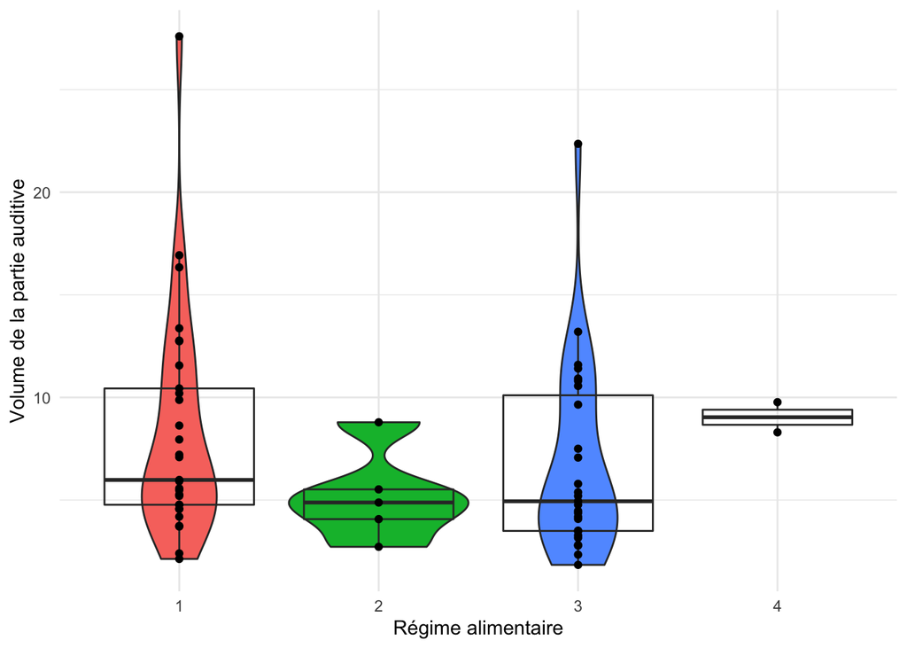

```r
ggplot(myData) +
   aes(x = Diet, y = AUD) +
   geom_violin(aes(fill = Diet)) +
   geom_boxplot(alpha = 0) +
   geom_point() +
   theme_minimal() +
   theme(legend.position = "none") +
   labs(x = "Régime alimentaire", y = "Volume de la partie auditive")
```

## Analyse de la variance à un facteur

### Modèle

On cherche à modéliser le volume de la partie auditive en fonction régime alimentaire, une variable qualitative. Le modèle mathématique associé est donc

$$Y_{i,k} = \mu + \alpha_i + E_{i,k},$$
où

- $Y_{i,k}$ est le volume de la partie auditive du $k^{\text{ème}}$ individu de la $i^{\text{ème}}$ diète,
- $\mu$ est l’effet moyen,
- $\alpha_{i}$ est l’effet spécifique de la diète $i$,
- $\left\{E_{i,k}\right\} \overset{iid}{\sim} \mathcal{N}\left(0, \sigma^2\right)$,
- $1 \leq i \leq I = 4$,
- $1 \leq k \leq n_i$,
- $n_1 = 29$, $n_2 = 5$, $n_3 = 27$, $n_4 = 2$.

Avant de faire la regression linéaire, on vérifie la classe de la varibale `Diet`. C’est bien un facteur (on l’a modifié au début), on peut faire l’analyse.

```r
class(myData$Diet)
```

```
## [1] "factor"
```

```r
reg4 <- lm(AUD ~ Diet, data = myData)
reg4
```

```
##
## Call:
## lm(formula = AUD ~ Diet, data = myData)
##
## Coefficients:
## (Intercept)        Diet2        Diet3        Diet4
##      8.3093      -3.1133      -1.5886       0.7257
```

### Graphes de diagnostic

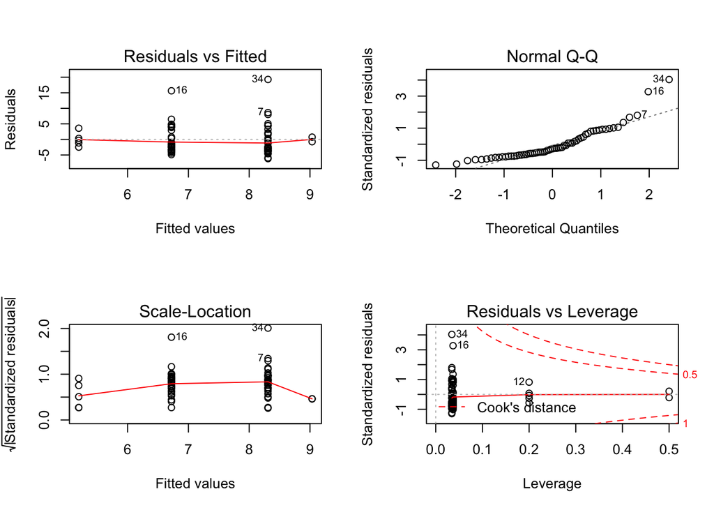

```r
par(mfrow = c(2, 2))
plot(reg4)
```

On valide toutes les hypothèses.

### Test du modèle

```r
reg4_0 <- lm(AUD ~ 1, data = myData)
anova(reg4_0, reg4)
```

```
## Analysis of Variance Table
##
## Model 1: AUD ~ 1
## Model 2: AUD ~ Diet
##   Res.Df    RSS Df Sum of Sq      F Pr(>F)
## 1     62 1464.3
## 2     59 1398.3  3    66.069 0.9293 0.4323
```

On effectue le test $H_0 = \{\alpha_1 = \alpha_2 = \alpha_3 = \alpha_4 = 0\}$ contre $H_1 = \{\exists i, \alpha_i \neq 0\}$. La statistique de test est $F_{obs}= 0.9293$ et on a $p>0.05$. On ne peut donc pas rejeter l’hypothèse nulle : notre modèle n’est pas significatif.

### Prise en compte de l’évolution

On peut effectuer une analyse de la variance à un facteur pour modéliser le volume de la partie auditive en fonction de la variable `Clade`.

```r
summary(lm(AUD ~ Clade, data = myData))
```

```
##
## Call:
## lm(formula = AUD ~ Clade, data = myData)
##
## Residuals:
##    Min     1Q Median     3Q    Max
## -5.988 -3.003 -1.151  2.048 19.239
##
## Coefficients:
##             Estimate Std. Error t value Pr(>|t|)
## (Intercept)   7.8281     1.0452   7.489 4.01e-10 ***
## CladeII       0.5328     1.4457   0.369    0.714
## CladeIII      3.7619     4.9026   0.767    0.446
## CladeIV      -2.3725     1.5385  -1.542    0.128
## ---
## Signif. codes:  0 '***' 0.001 '**' 0.01 '*' 0.05 '.' 0.1 ' ' 1
##
## Residual standard error: 4.79 on 59 degrees of freedom
## Multiple R-squared:  0.07559,    Adjusted R-squared:  0.02859
## F-statistic: 1.608 on 3 and 59 DF,  p-value: 0.1971
```

La p-valeur associée à cette modélisation est $p=0.1971>0.05$ donc le modèle n’est pas significatif.